# Module05 homework answers

Steve Simon

Created 2021-04-08

Questions 1-5 refer to the Albuquerque dataset.

1. Convert the number codes for the categorical variables to factors. Show frequency tables for these variables after conversion. Are any values missing for these categorical variables?

```r
fn <- "../data/albuquerque-housing.txt"
al <- read.table(fn, header=TRUE, sep=" ")
head(al)
```

```
##    price sqft age feats ne cust cor  tax
## 1 205000 2650  13     7  1    1   0 1639
## 2 208000 2600  NA     4  1    1   0 1088
## 3 215000 2664   6     5  1    1   0 1193
## 4 215000 2921   3     6  1    1   0 1635
## 5 199900 2580   4     4  1    1   0 1732
## 6 190000 2580   4     4  1    0   0 1534
```

```r
al$ne_factor <-
  factor(
    al$ne,
    levels=0:1,
    labels=c("No", "Yes"))
table(al$ne_factor, useNA="always")
```

```
##
##   No  Yes <NA>
##   39   78    0
```

```r
al$custom_factor <-
  factor(
    al$cust,
    levels=0:1,
    labels=c("No", "Yes"))
table(al$custom_factor, useNA="always")
```

```
##
##   No  Yes <NA>
##   90   27    0
```

```r
al$corner_factor <-
  factor(
    al$cor,
    levels=0:1,
    labels=c("No", "Yes"))
table(al$corner_factor, useNA="always")
```

```
##
##   No  Yes <NA>
##   95   22    0
```

There are no missing values for any of these three variables.

2. Compute means and standard deviations for all the continuous variables. How many missing values are there for age and for tax?

```r
mean(al$price, na.rm=TRUE)
```

```
## [1] 106273.5
```

```r
sd(al$price, na.rm=TRUE)
```

```
## [1] 38043.7
```

```r
sum(is.na(al$price))
```

```
## [1] 0
```

```r
mean(al$sqft, na.rm=TRUE)
```

```
## [1] 1653.855
```

```r
sd(al$sqft, na.rm=TRUE)
```

```
## [1] 523.7228
```

```r
sum(is.na(al$sqft))
```

```
## [1] 0
```

```r
mean(al$age, na.rm=TRUE)
```

```
## [1] 14.97059
```

```r
sd(al$age, na.rm=TRUE)
```

```
## [1] 12.66912
```

```r
sum(is.na(al$age))
```

```
## [1] 49
```

There are 49 missing values for age.

```r
mean(al$feats, na.rm=TRUE)
```

```
## [1] 3.529915
```

```r
sd(al$feats, na.rm=TRUE)
```

```
## [1] 1.405486
```

```r
sum(is.na(al$freats))
```

```
## [1] 0
```

Note: some people would consider the number of features out of 11 as a categorical variable rather than a continuous variable. I won’t deduct any points if you do or do not include it here.

```r
mean(al$tax, na.rm=TRUE)
```

```
## [1] 793.486
```

```r
sd(al$tax, na.rm=TRUE)
```

```
## [1] 308.1803
```

```r
sum(is.na(al$tax))
```

```
## [1] 10
```

There are 10 missing values for tax.

3. Find the largest house (biggest square footage) in the data set. Is the largest house also the most expensive house?

```r
biggest_house <- which(al$sqft==max(al$sqft))
al[biggest_house, ]
```

```
##     price sqft age feats ne cust cor  tax ne_factor custom_factor corner_factor
## 79 129500 3750  NA     4  0    1   1 1200        No           Yes           Yes
```

```r
most_expensive <- which(al$price==max(al$price))
al[most_expensive, ]
```

```
##     price sqft age feats ne cust cor  tax ne_factor custom_factor corner_factor
## 3  215000 2664   6     5  1    1   0 1193       Yes           Yes            No
## 4  215000 2921   3     6  1    1   0 1635       Yes           Yes            No
## 47 215000 2848   4     6  1    1   0 1487       Yes           Yes            No
```

The biggest house is 3,750 square feet, but it only sold for $129,500. There are three houses that sold for the maximum price, $215,000.

4. Evaluate the relationship between PRICE and SQFT using a scatterplot. Do larger houses tend to cost more?

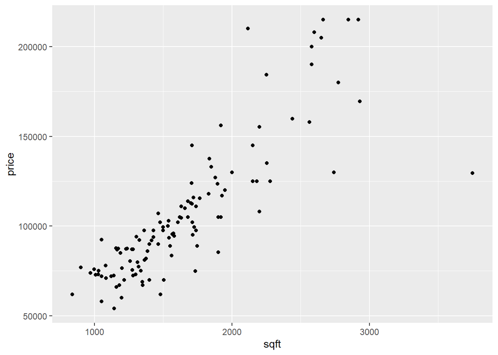

```r
library(ggplot2)
ggplot(al, aes(x=sqft, y=price)) +
  geom_point()
```

Larger houses do indeed tend to cost more.

5. Show how much more expensive custom built homes are compared to standard homes using a boxplot and through calculation of the means and standard deviations.

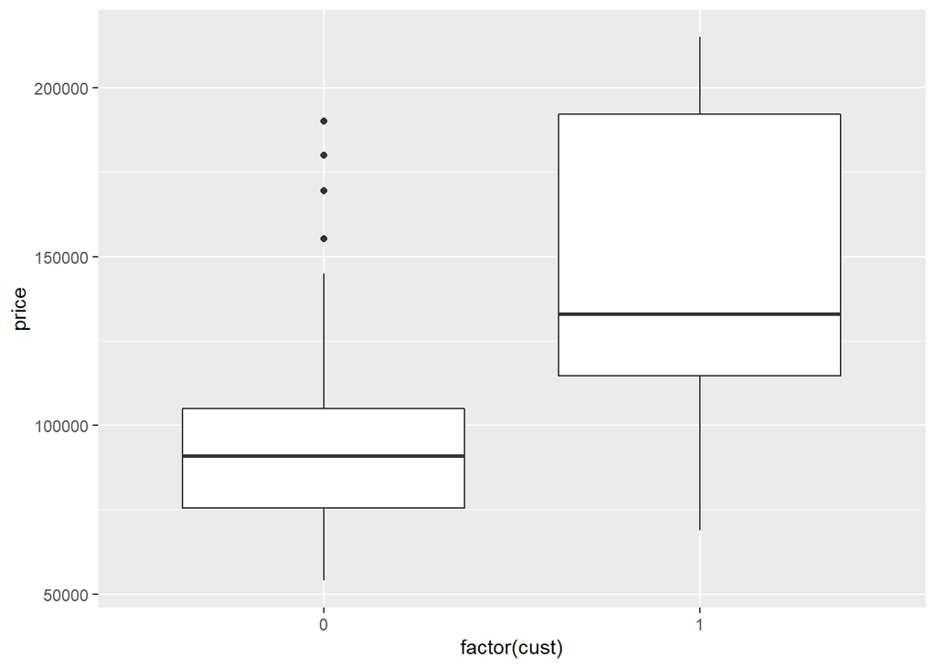

```r
ggplot(al, aes(x=factor(cust), y=price)) +
  geom_boxplot()
```

```r
price_means <- by(al$price, al$cust, mean, na.rm=TRUE)
price_means
```

```
## al$cust: 0
## [1] 94752.22
## ------------------------------------------------------------
## al$cust: 1
## [1] 144677.8
```

```r
price_sdev <- by(al$price, al$cust, sd, na.rm=TRUE)
price_sdev
```

```
## al$cust: 0
## [1] 25365.65
## ------------------------------------------------------------
## al$cust: 1
## [1] 47578.63
```

Coustom built houses are about $50,000 more expensive on average.

Questions 6-7 refer to the Diamond dataset.

6. Show the relationship between carat size and price using a scatterplot.

```r
fn <- "http://jse.amstat.org/v9n2/4Cdata.txt"
di <- read.table(fn)
names(di) <- c("carat", "color", "clarity", "certification", "price")
head(di)
```

```
##   carat color clarity certification price
## 1  0.30     D     VS2           GIA  1302
## 2  0.30     E     VS1           GIA  1510
## 3  0.30     G    VVS1           GIA  1510
## 4  0.30     G     VS1           GIA  1260
## 5  0.31     D     VS1           GIA  1641
## 6  0.31     E     VS1           GIA  1555
```

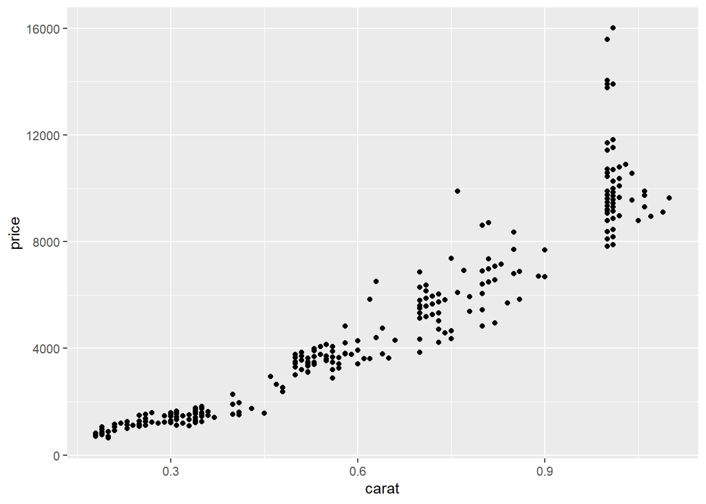

```r
ggplot(di, aes(x=carat, y=price)) +
  geom_point()
```

7. Show the relationship between color and price and the relatonship between clarity and price using boxplots.

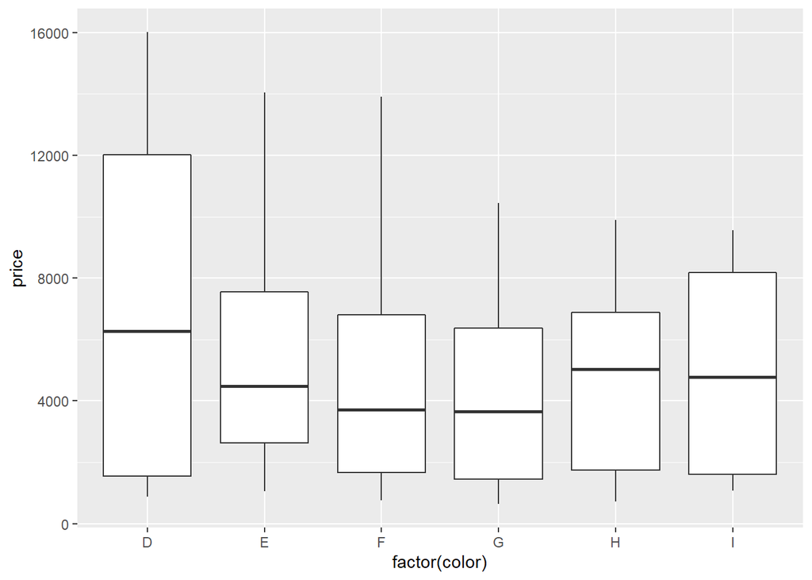

```r
ggplot(di, aes(x=factor(color), y=price)) +
  geom_boxplot()
```